# Fraud Detection - Data Challenge

Company XYZ is an e-commerce site that sells hand-made clothes. You have to build a model that predicts whether a user has a high probability of using the site to perform some illegal activity or not.

You only have information about the user first transaction on the site and based on that you have to make your classification (“fraud/no fraud”).

These are the tasks you are asked to do:

For each user, determine her country based on the numeric IP address.

Build a model to predict whether an activity is fraudulent or not. Explain how different assumptions about the cost of false positives vs false negatives would impact the model.

Your boss is a bit worried about using a model she doesn’t understand for something as important as fraud detection. How would you explain her how the model is making the predictions? Not from a mathematical perspective (she couldn’t care less about that), but from a user perspective. What kinds of users are more likely to be classified as at risk? What are their characteristics?

Let’s say you now have this model which can be used live to predict in real time if an activity is fraudulent or not.

From a product perspective, how would you use it? That is, what kind of different user experiences would you build based on the model output?

Data: “Fraud_Data” - information about each user first transaction

Columns:

user_id : Id of the user. Unique by user signup_time : the time when the user created her account (GMT time) purchase_time : the time when the user bought the item (GMT time) purchase_value : the cost of the item purchased (USD) device_id : the device id. You can assume that it is unique by device. I.e., transaJtions with the same device ID means that the same physical device was used to buy source : user marketing channel: ads, SEO, Direct (i.e. came to the site by directly typing the site address on the browser). browser : the browser used by the user. sex : user sex: Male/Female age : user age ip_address : user numeric ip address class : this is what we are trying to predict: whether the activity was fraudulent (1) or not (0). “IpAddress_to_Country” - mapping each numeric ip address to its country. For each country, it gives a range. If the numeric ip address falls within the range, then the ip address belongs to the corresponding country.

Columns:

```r
#load libraries
library(dplyr)
library(corrplot)
library(ggplot2)
```

## Read from CSV File

```r
fraudData= read.csv('C:\\Data Challenge\\Fraud_Data.csv', header = TRUE, stringsAsFactor = FALSE)
str(fraudData)
```

```
## 'data.frame':    151112 obs. of  11 variables:
##  $ user_id       : int  226648 103319 36633 64674 299963 314594 100914 325729 254993 209275 ...
##  $ signup_time   : chr  "5/12/2015 16:00" "2/5/2015 22:20" "5/10/2015 0:49" "1/1/2015 4:25" ...
##  $ purchase_time : chr  "6/13/2015 23:42" "3/29/2015 0:39" "7/22/2015 3:18" "1/1/2015 4:25" ...
##  $ purchase_value: int  45 94 46 57 57 57 57 57 57 57 ...
##  $ device_id     : chr  "AAALBGNHHVMKG" "AAAWIHVCQELTP" "AAAXJHWCLISKY" "AAAXXOZJRZRAO" ...
##  $ source        : chr  "Direct" "Ads" "Ads" "Ads" ...
##  $ browser       : chr  "Chrome" "Chrome" "IE" "FireFox" ...
##  $ sex           : chr  "M" "M" "M" "F" ...
##  $ age           : int  34 29 40 36 36 36 36 36 36 36 ...
##  $ ip_address    : num  2.49e+09 8.09e+08 2.89e+06 1.38e+09 1.38e+09 ...
##  $ class         : int  0 0 0 1 1 1 1 1 1 0 ...
```

## EDA

```r
sum(rowSums(is.na(fraudData)))
```

```
## [1] 0
```

```r
summary(fraudData)
```

```
##     user_id       signup_time        purchase_time      purchase_value
##  Min.   :     2   Length:151112      Length:151112      Min.   :  9.00
##  1st Qu.:100643   Class :character   Class :character   1st Qu.: 22.00
##  Median :199958   Mode  :character   Mode  :character   Median : 35.00
##  Mean   :200171                                         Mean   : 36.94
##  3rd Qu.:300054                                         3rd Qu.: 49.00
##  Max.   :400000                                         Max.   :154.00
##   device_id            source            browser
##  Length:151112      Length:151112      Length:151112
##  Class :character   Class :character   Class :character
##  Mode  :character   Mode  :character   Mode  :character
##
##
##
##      sex                 age          ip_address            class
##  Length:151112      Min.   :18.00   Min.   :5.209e+04   Min.   :0.00000
##  Class :character   1st Qu.:27.00   1st Qu.:1.086e+09   1st Qu.:0.00000
##  Mode  :character   Median :33.00   Median :2.155e+09   Median :0.00000
##                     Mean   :33.14   Mean   :2.152e+09   Mean   :0.09365
##                     3rd Qu.:39.00   3rd Qu.:3.243e+09   3rd Qu.:0.00000
##                     Max.   :76.00   Max.   :4.295e+09   Max.   :1.00000
```

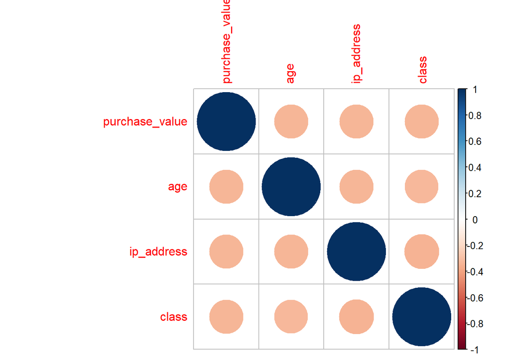

```r
#correlation of numeric variables
numericCols = fraudData[,sapply(fraudData, is.numeric)]
fdCor = cor(numericCols[,-1], use="complete.obs")
corrplot(cor(fdCor), method = "circle")
```

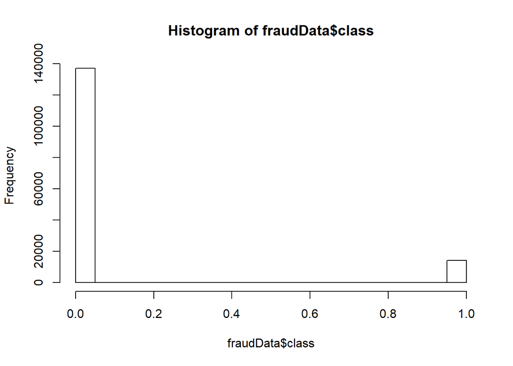

```r
hist(fraudData$class)
```

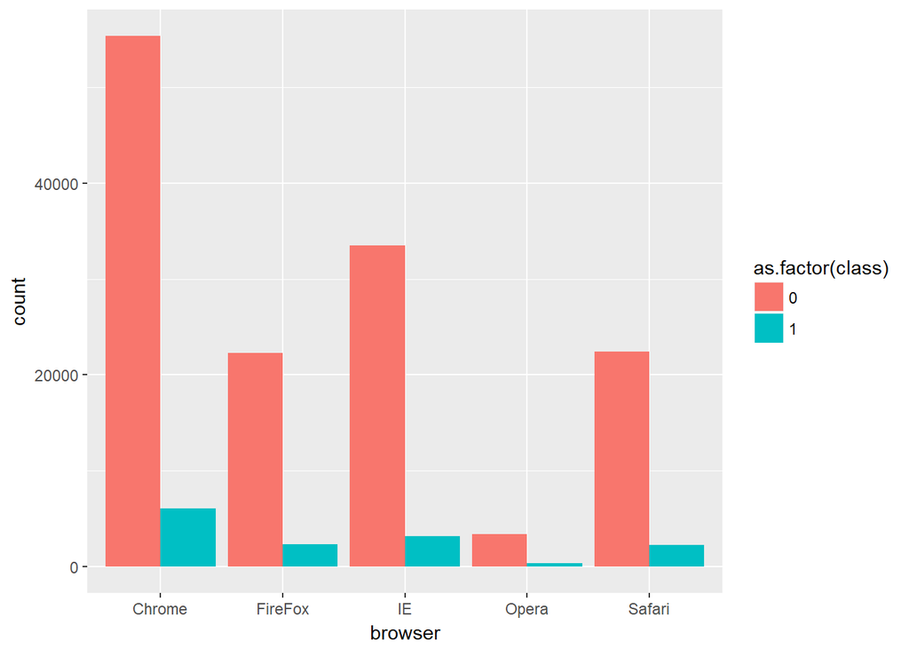

```r
#ggplot(fraudData, aes(x=sex, y = SalePrice))+ geom_col() + coord_flip()

#relation between browser and class
ggplot(fraudData, aes(browser, ..count..)) + geom_bar(aes(fill = as.factor(class)), position = "dodge")
```

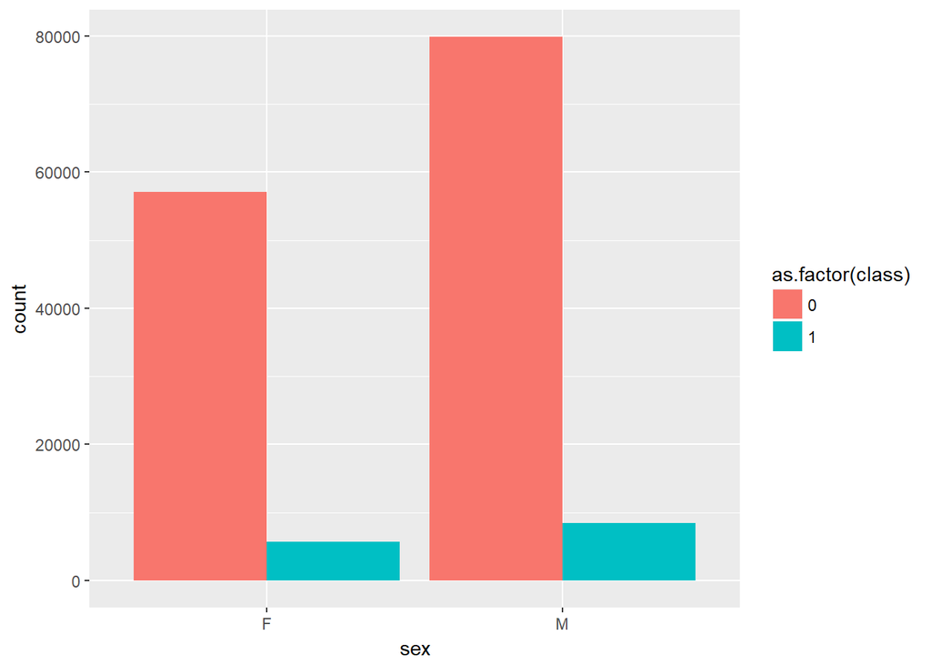

```r
#relation between sex and class
ggplot(fraudData, aes(sex, ..count..)) + geom_bar(aes(fill = as.factor(class)), position = "dodge")
```

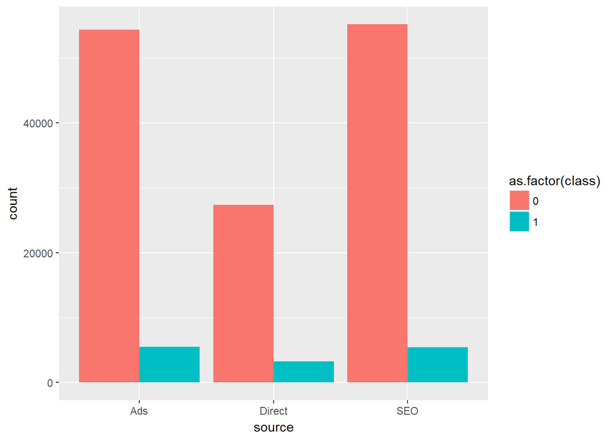

```r
#relation between source and class
ggplot(fraudData, aes(source, ..count..)) + geom_bar(aes(fill = as.factor(class)), position = "dodge")
```

[figure not shown]

```r
#relation between ip_address and class
ggplot(fraudData, aes(ip_address, ..count..)) + geom_bar(aes(fill = as.factor(class)), position = "dodge")
```

##Features Engineering

###Country - IPAddress Mapping

```r
library(data.table)
#get country country - ipaddress mapping
countryIP = read.csv('C:\\Data Challenge\\IpAddress_to_Country.csv',header = TRUE, stringsAsFactor = FALSE)

dt1 <- data.table(fraudData)
dt1[, extra_ip_address := ip_address]
dt2 <- data.table(countryIP)
setkey(dt2, lower_bound_ip_address, upper_bound_ip_address)

result <- foverlaps(dt1, dt2, by.x=c('ip_address', 'extra_ip_address'),
                    by.y=c('lower_bound_ip_address', 'upper_bound_ip_address'))

fraudDatawithcountry = data.frame(result)
fraudDatawithcountry[is.na(fraudDatawithcountry$country),]$country = "Not Available"
fraudDatawithcountry[,c("extra_ip_address","lower_bound_ip_address","upper_bound_ip_address")] = NULL
tail(fraudDatawithcountry)
```

```
##              country user_id     signup_time    purchase_time
## 151107 United States   62337 1/13/2015 18:05  4/20/2015 19:07
## 151108 United States  291289  4/5/2015 21:31   4/12/2015 4:54
## 151109       Austria    6741  8/16/2015 9:46 10/24/2015 17:29
## 151110 United States  122422  8/9/2015 14:05    9/7/2015 3:15
## 151111         Japan  359303 5/10/2015 11:55   8/6/2015 10:45
## 151112 Not Available  142603  5/8/2015 19:20  5/23/2015 19:19
##        purchase_value     device_id source browser sex age ip_address
## 151107             52 ZZZFMEPPCQVFV    SEO      IE   F  19 1184912379
## 151108             18 ZZZGSIJRNCXBJ    Ads  Safari   F  33 2553895471
## 151109             55 ZZZIKLJSVSQMF    Ads      IE   M  41 3265673644
## 151110             59 ZZZKJIZHJEDFN Direct  Safari   M  33 2415066584
## 151111             49 ZZZMVOGBAJVTM    Ads  Chrome   M  25 3404179484
## 151112             82 ZZZXASJUVUNMV Direct  Chrome   F  56 4035153773
##        class
## 151107     0
## 151108     0
## 151109     0
## 151110     0
## 151111     0
## 151112     0
```

[figure not shown]

```r
#relation between country and class
ggplot(fraudDatawithcountry, aes(country, ..count..)) + geom_bar(aes(fill = as.factor(class)), position = "dodge") + theme(axis.text.x = element_text(angle = 90, hjust = 1))
```

```r
##If country variable is converted to 'factors', it has 182 levels - is not a useful variable for training models
```

###Preparing Data

```r
library(lubridate)
#Convert date to numeric
#convert dates to numeric
library(lubridate)


fraudData$signup_Year = format(as.Date(fraudData$signup_time,"%m/%d/%Y"),"%Y")
fraudData$signup_Month = format(as.Date(fraudData$signup_time,"%m/%d/%Y"),"%m")
fraudData$signup_Day = format(as.Date(fraudData$signup_time,"%m/%d/%Y"),"%d")

fraudData$purchase_Year = format(as.Date(fraudData$purchase_time,"%m/%d/%Y"),"%Y")
fraudData$purchase_Month = format(as.Date(fraudData$purchase_time,"%m/%d/%Y"),"%m")
fraudData$purchase_Day = format(as.Date(fraudData$purchase_time,"%m/%d/%Y"),"%d")

fraudData$signup_Time = format(strptime(fraudData$signup_time,"%m/%d/%Y %H:%M",tz=""),"%H:%M")
fraudData$signup_Time = as.POSIXct(fraudData$signup_Time,format="%H:%M")
fraudData$purchase_Time = format(strptime(fraudData$purchase_time,"%m/%d/%Y %H:%M",tz=""),"%H:%M")
fraudData$purchase_Time = as.POSIXct(fraudData$purchase_Time,format="%H:%M")
fraudData$time_lapse = as.Date(fraudData$purchase_time, "%m/%d/%Y %H:%M",tz="") - as.Date(fraudData$signup_time, "%m/%d/%Y %H:%M",tz="")


#remove device_id
#In our data set device_id corresponds to ip address - in reality device_id cannot be spoofed as ip address
fraudData[,c(2,3,5)] = NULL

#convert character data to factors
fraudData$source = as.factor(fraudData$source)
fraudData$browser = as.factor(fraudData$browser)
fraudData$sex = as.factor(fraudData$sex)
fraudData$class = as.factor(fraudData$class)

#separate train and test sets 70-30
set.seed(0)
train = sample(1:nrow(fraudData), nrow(fraudData)*0.7)
test = fraudData[-train,]
train = fraudData[train,]
```

##Training & Prediction

```r
library(caret)
```

##Random Forest - Determine Variable importance

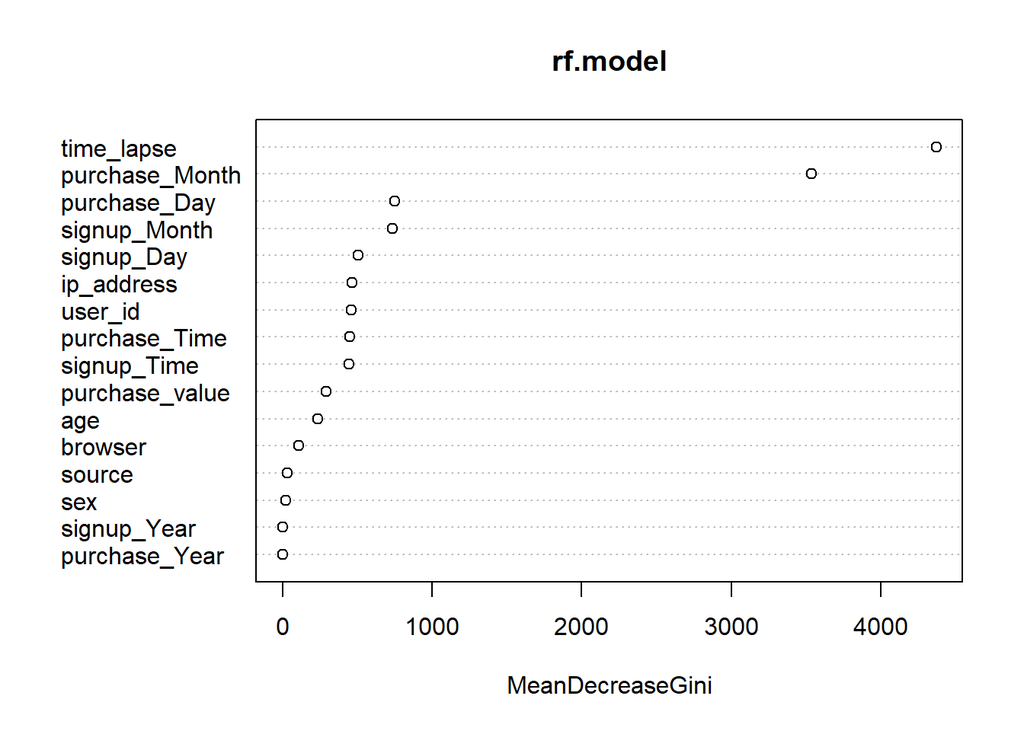

```r
library(randomForest)
set.seed(10)
rf.model = randomForest(class ~ ., data = train, ntree = 100, nodesize = 20)
#rf.predict <- predict(rf.model, test)
#confusionMatrix(test$class, rf.predict)
varImpPlot(rf.model)
```

##Logistic Regression

```r
library(stats)
glm.model = glm(class ~ purchase_Month, data = train, family = "binomial") #, control = list(maxit = 50))
glm.predict = predict(glm.model, test, type = "response")
glm.predict=ifelse(glm.predict>0.5,1,0)
lm.ac=length(which(glm.predict==test$class))
lm.ac=lm.ac/nrow(test)
#Accuracy
lm.ac
```

```
## [1] 0.94192
```

##Advantages #####1. Real-time processing #####2. Reduced number of verification methods #####3. Minimize fraud detection time (automatic detection)

##References

######https://rpubs.com/kieroneil/321413 ######https://www.marutitech.com/machine-learning-fraud-detection/ ######https://nycdatascience.com/blog/student-works/credit-card-fraud-detection/ ######https://www.bue.edu.eg/pdfs/Research/ACE/5%20Online%20Proceeding/9%20Artificial%20Intelligence%20Techniques%20&%20Applications%20(ETI02)/Data%20Mining%20Techniques%20for%20Credit%20Card%20Fraud%20Detection%20Empirical%20Study.pdf